# **Average error**

Figures illustrate the Boxplots and Kruskal–Wallis test results for different strategies for average error values.

## **50D scenario**

**Function:** *f1**

`Standard error of all strategies equal to or very close to zero.`

**Function:** *f2**

`Standard error of all strategies equal to or very close to zero.`

**Function:** *f3**

`Standard error of all strategies equal to or very close to zero.`

**Function:** *f4**

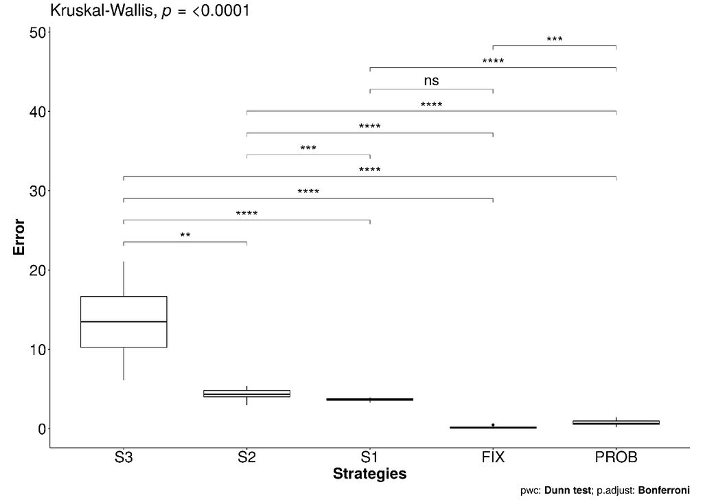

**Function:** *f5**

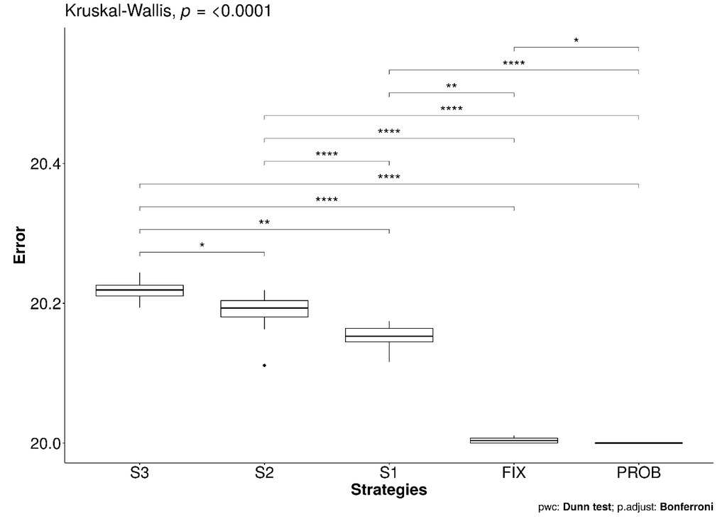

**Function:** *f6**

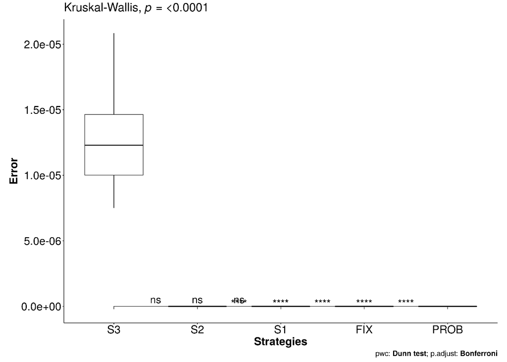

**Function:** *f7**

`Standard error of all strategies equal to or very close to zero.`

**Function:** *f8**

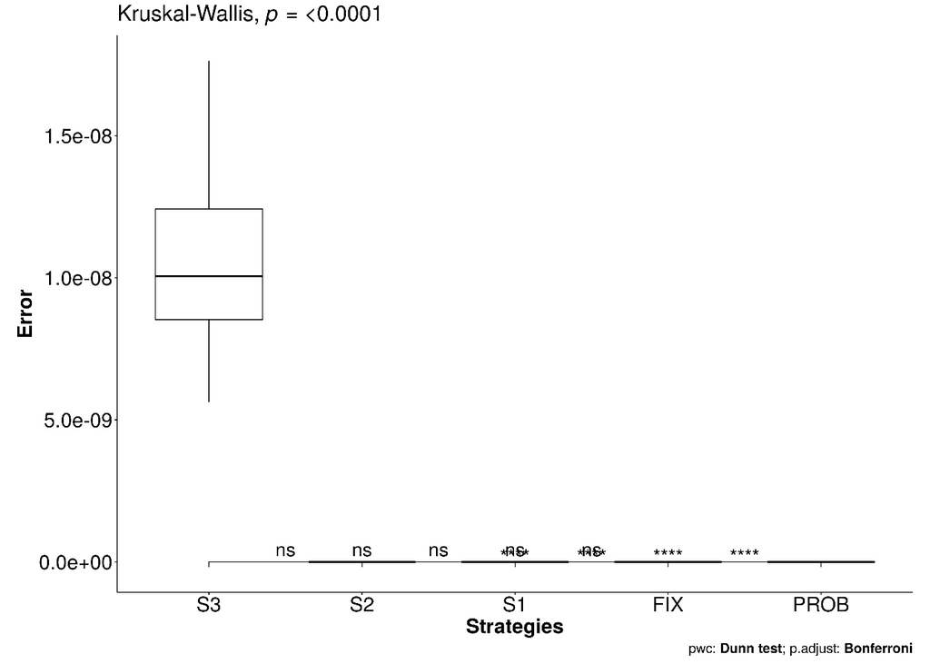

**Function:** *f9**

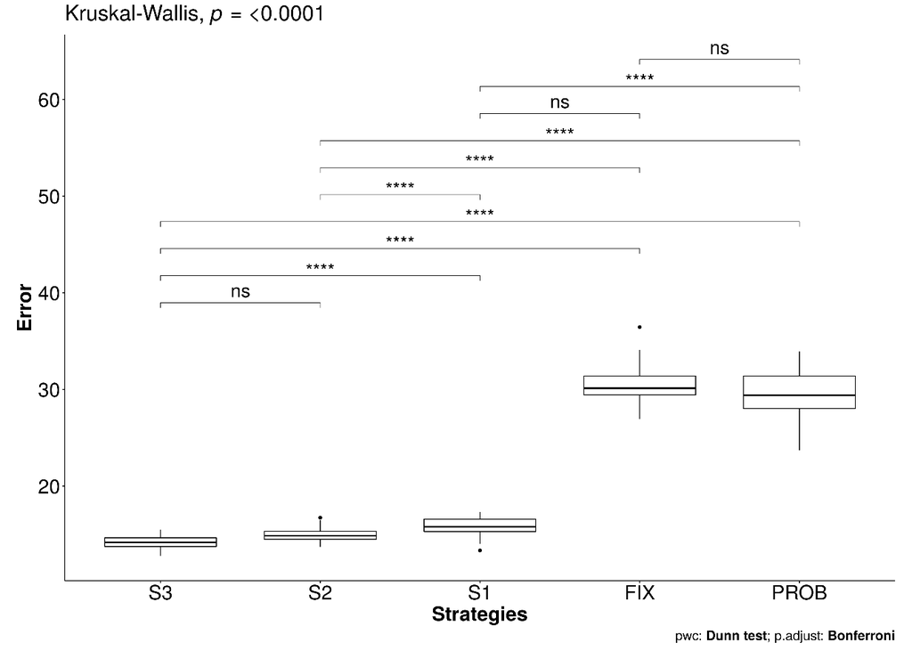

**Function:** *f10**

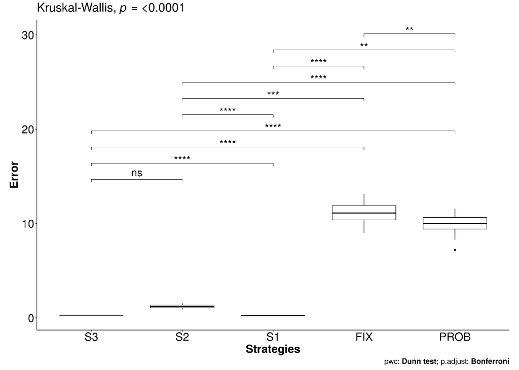

**Function:** *f11**

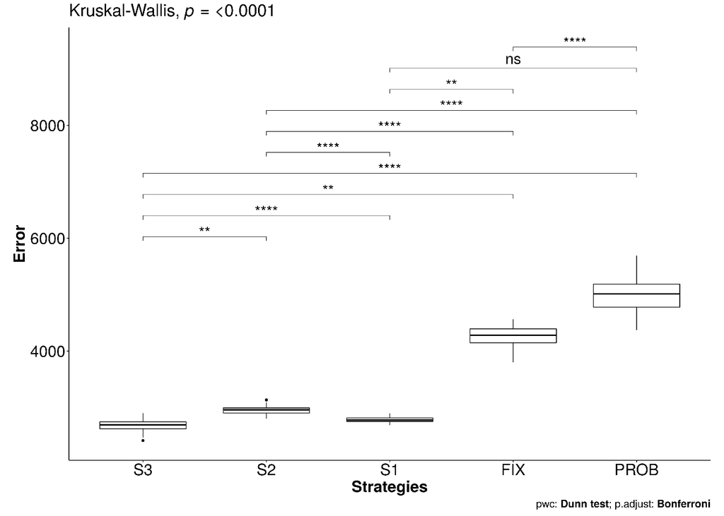

**Function:** *f12**

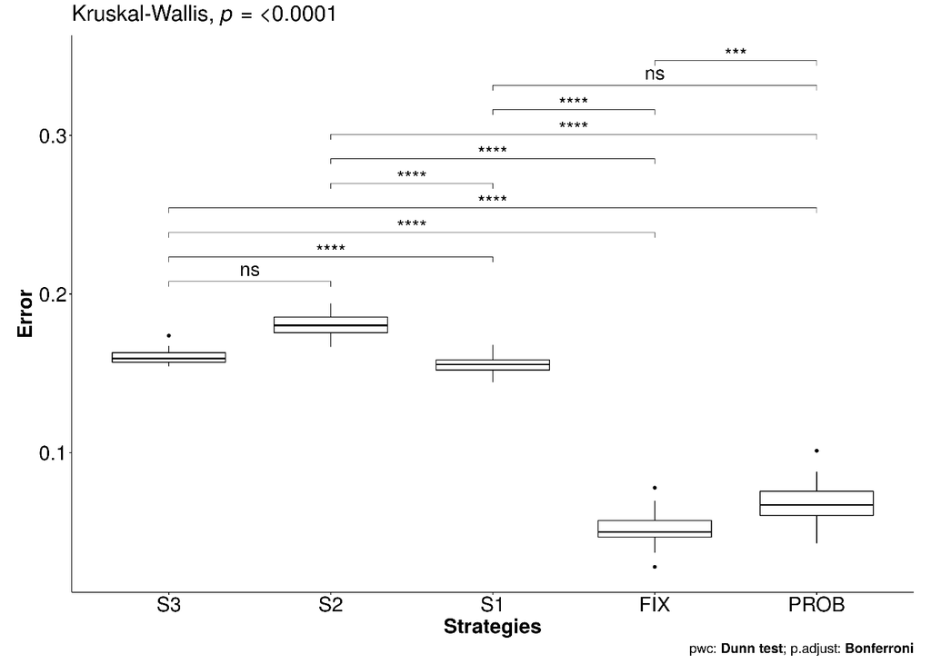

**Function:** *f13**

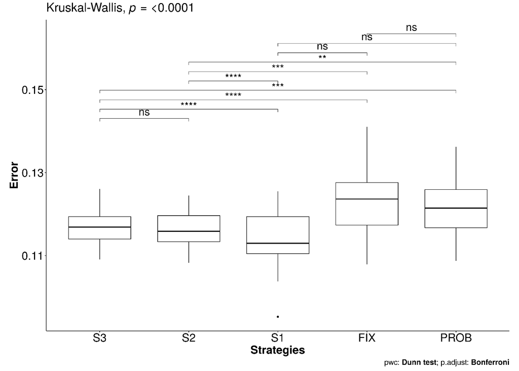

**Function:** *f14**

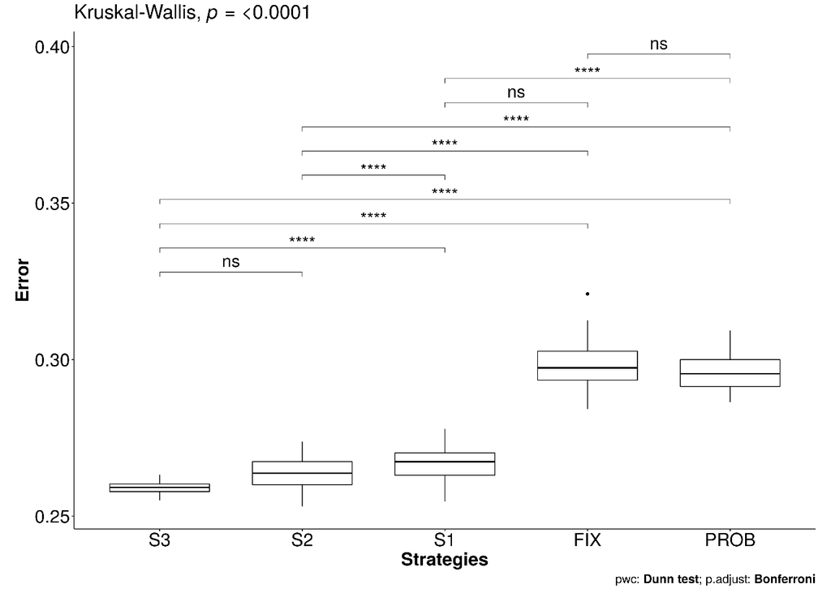

**Function:** *f15**

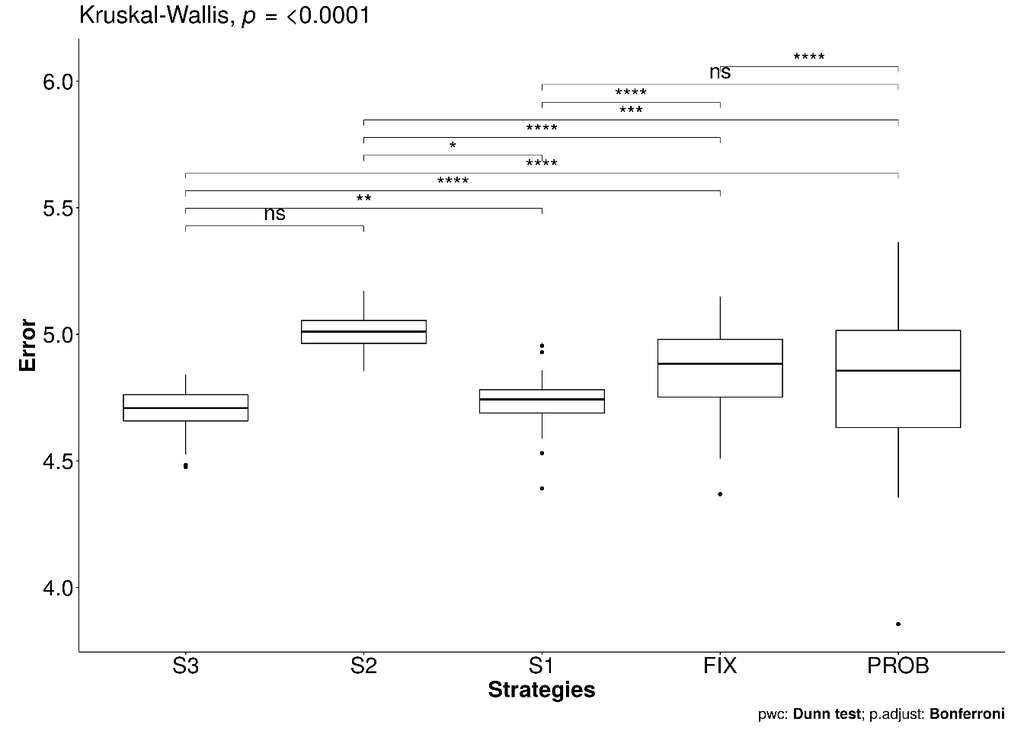

**Function:** *f16**

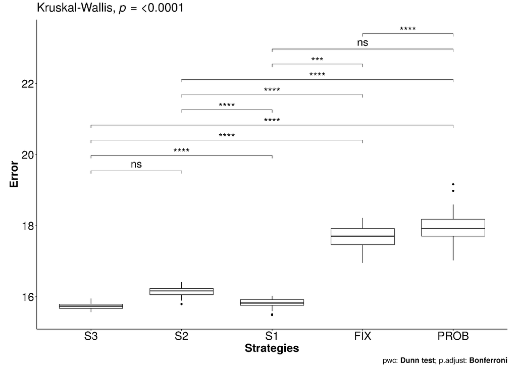

**Function:** *f17**

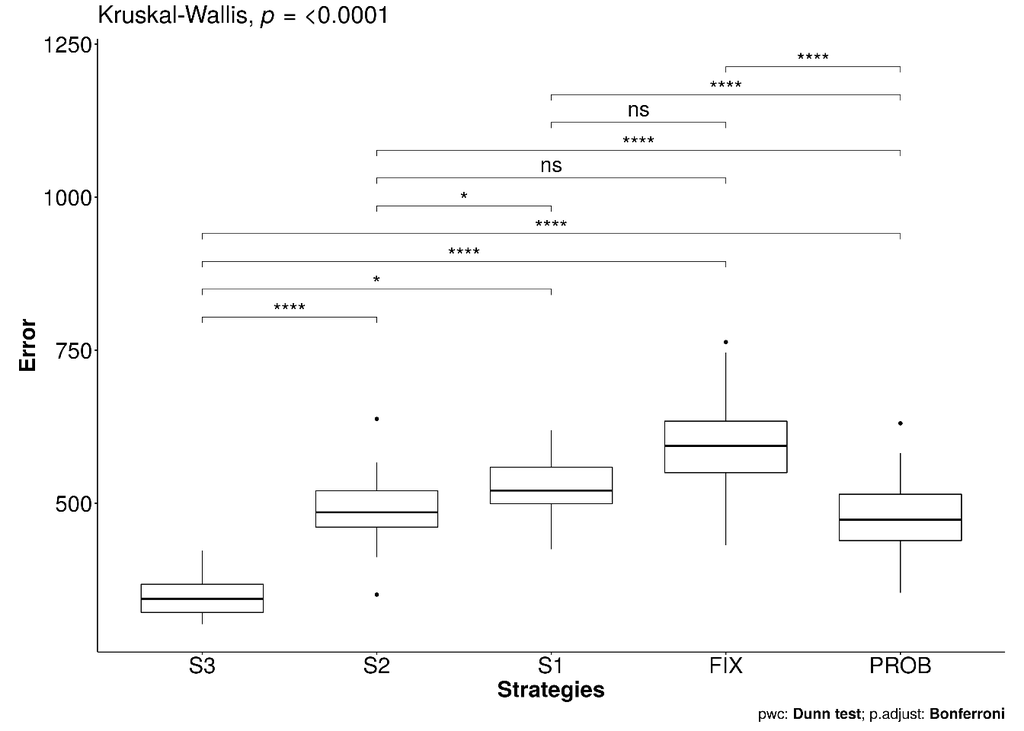

**Function:** *f18**

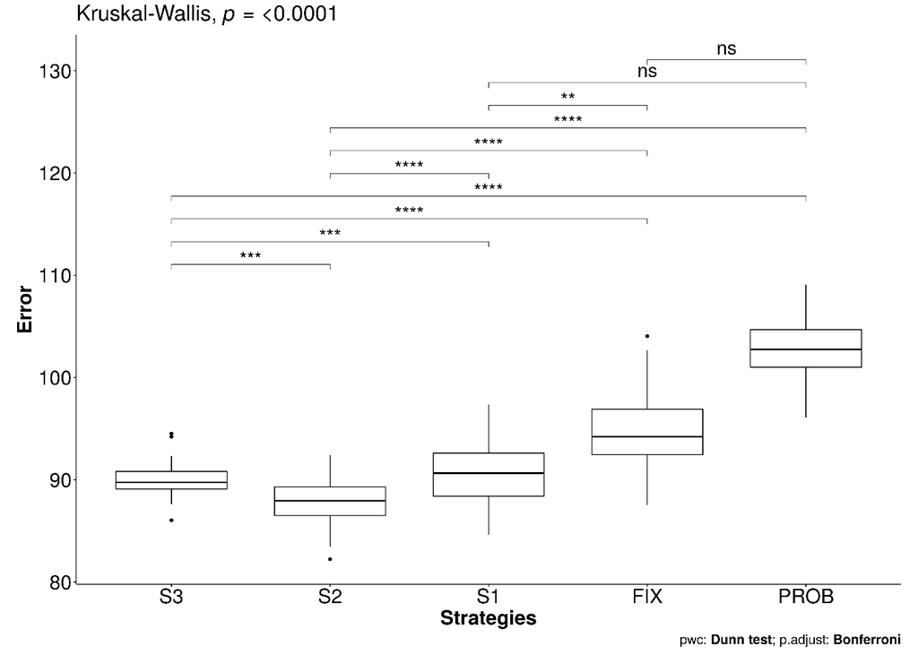

**Function:** *f19**

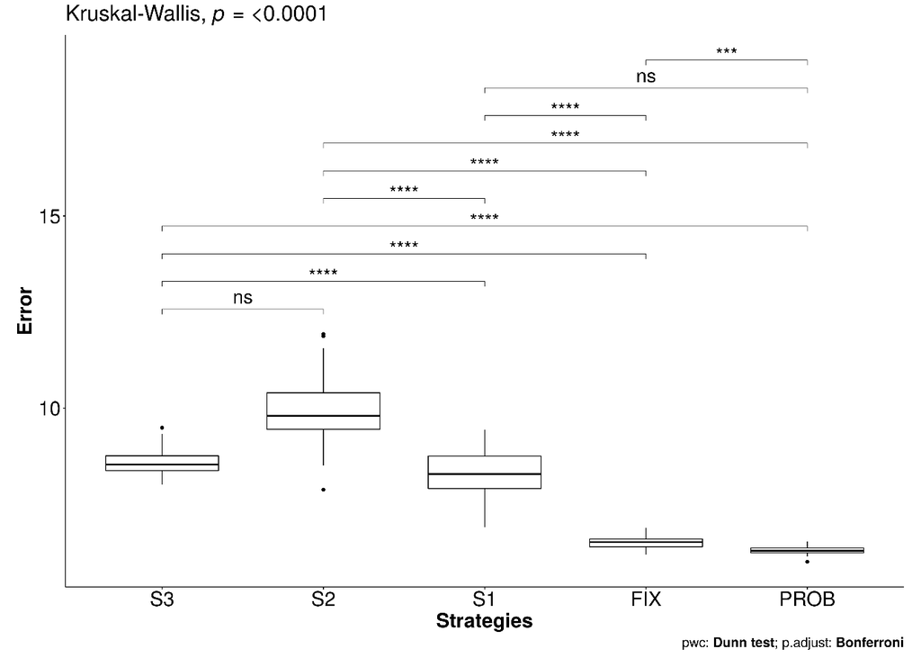

**Function:** *f20**

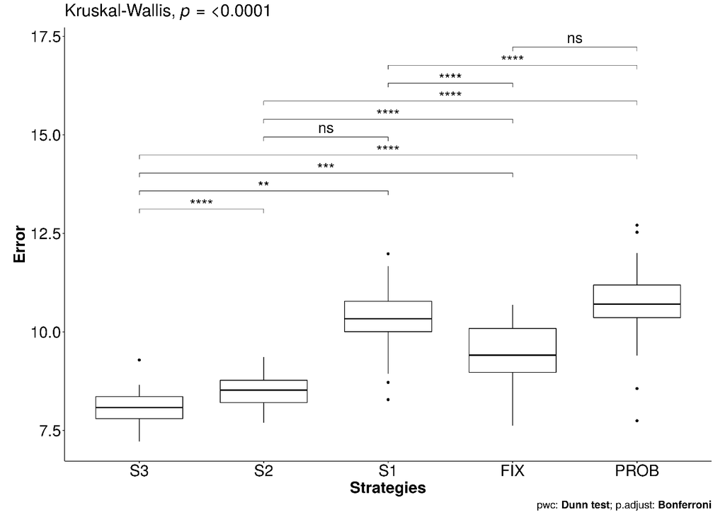

**Function:** *f21**

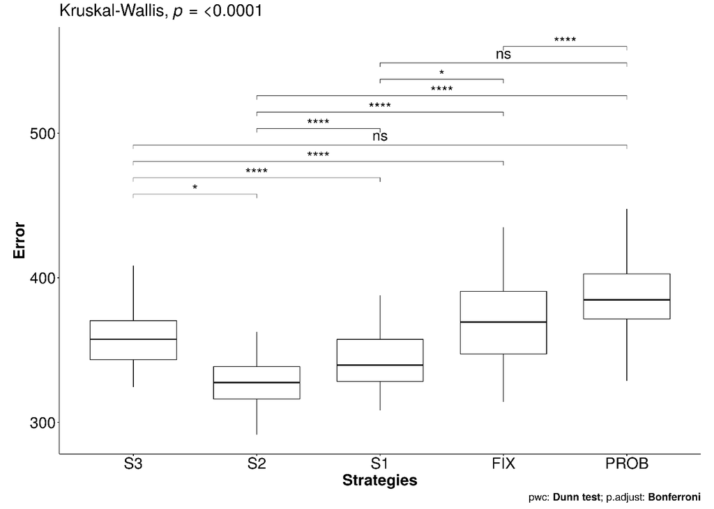

**Function:** *f22**

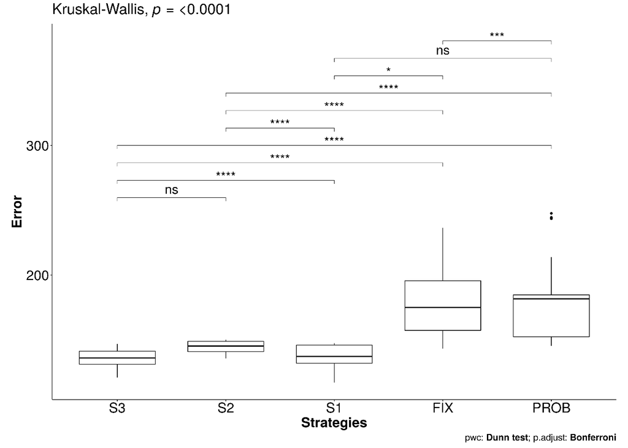

**Function:** *f23**

`Standard error of all strategies equal to or very close to zero.`

**Function:** *f24**

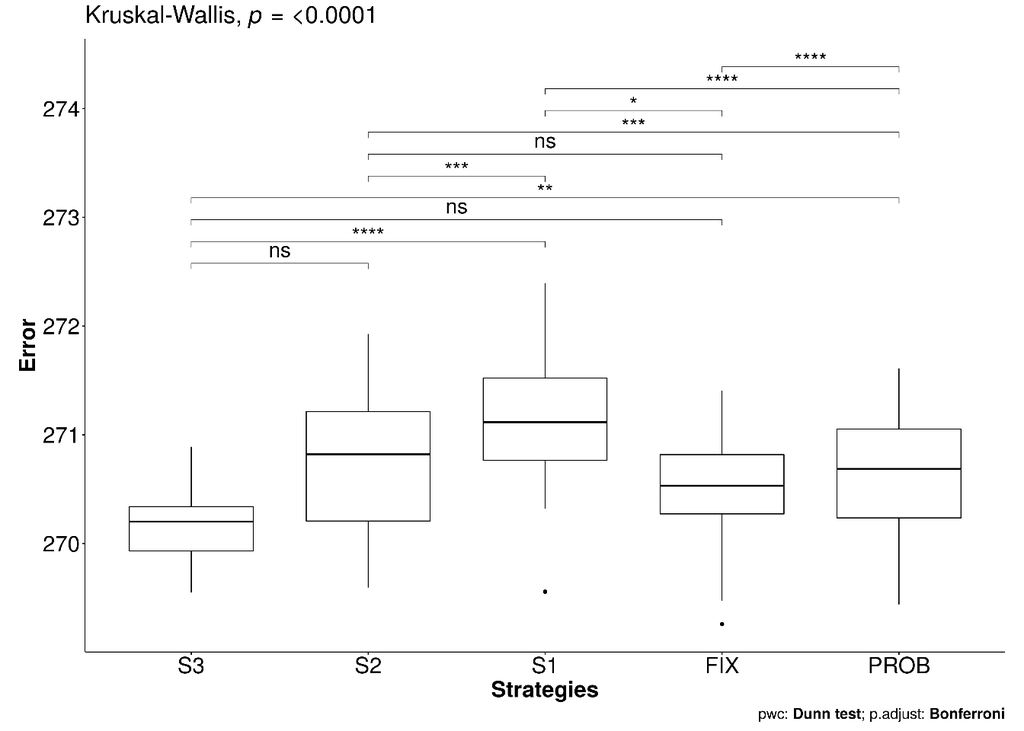

**Function:** *f25**

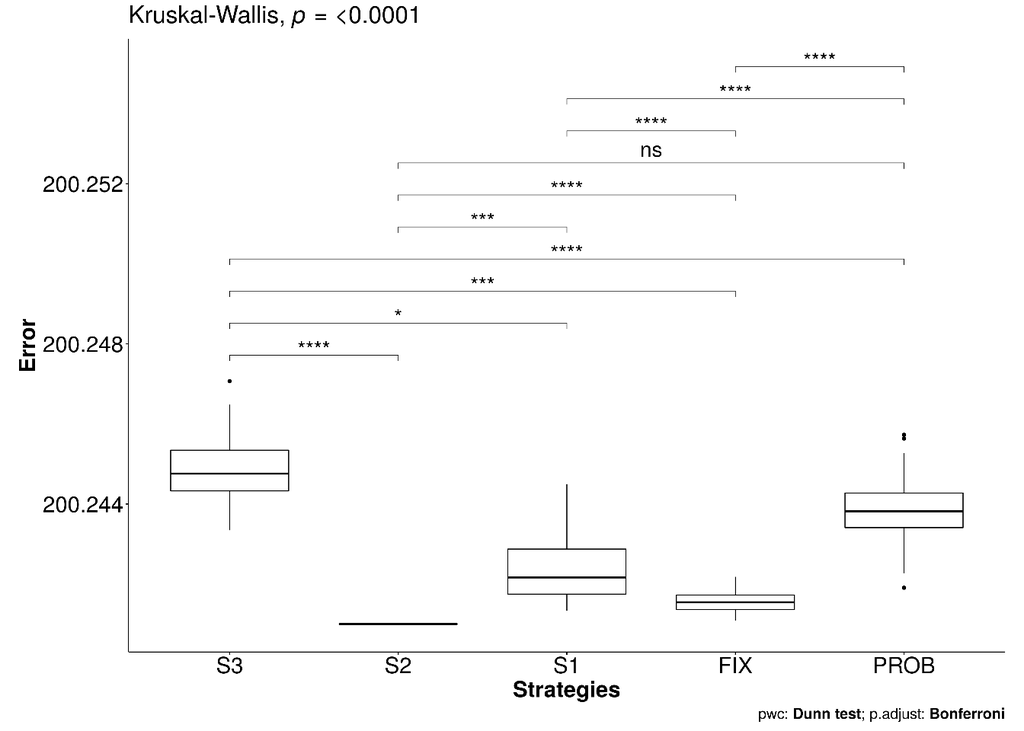

**Function:** *f26**

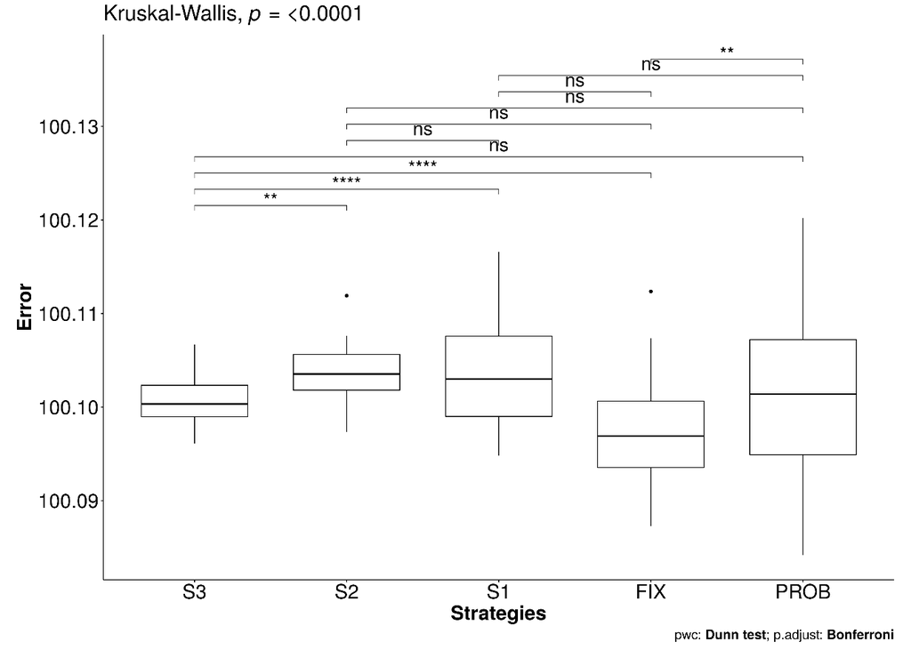

**Function:** *f27**

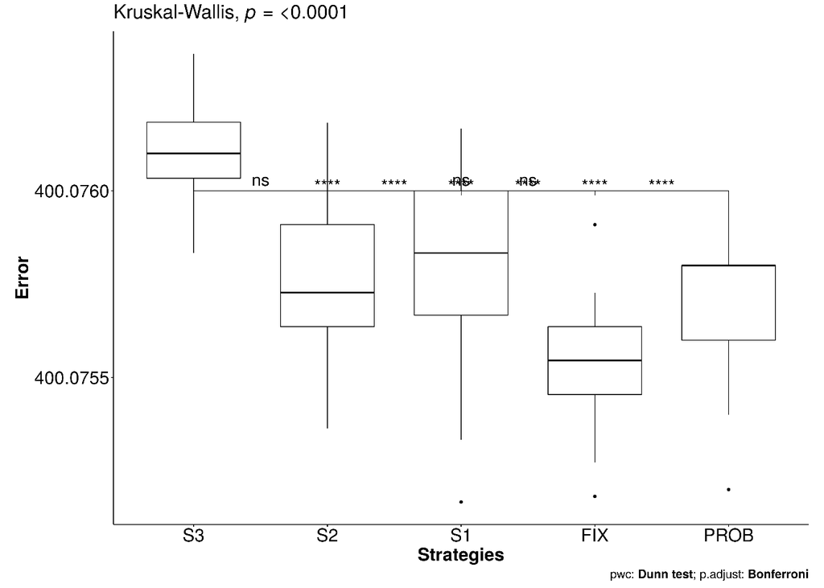

**Function:** *f28**

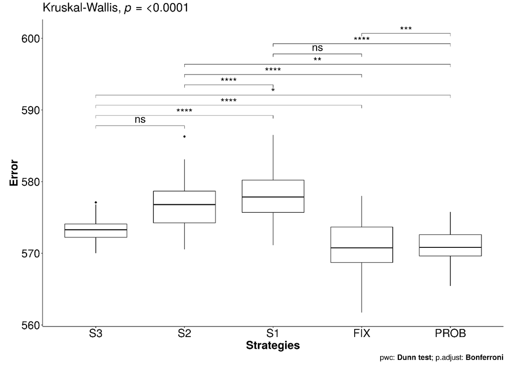

**Function:** *f29**

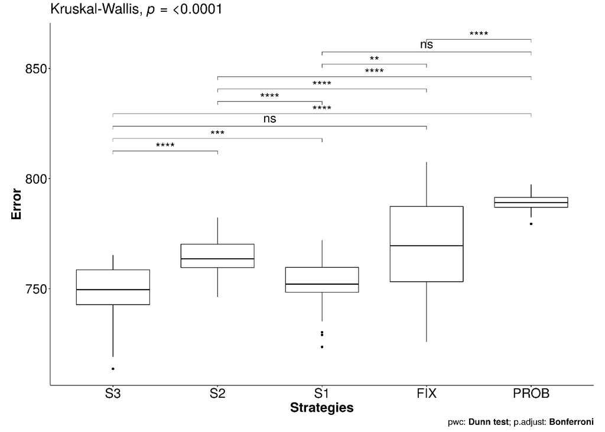

**Function:** *f30**

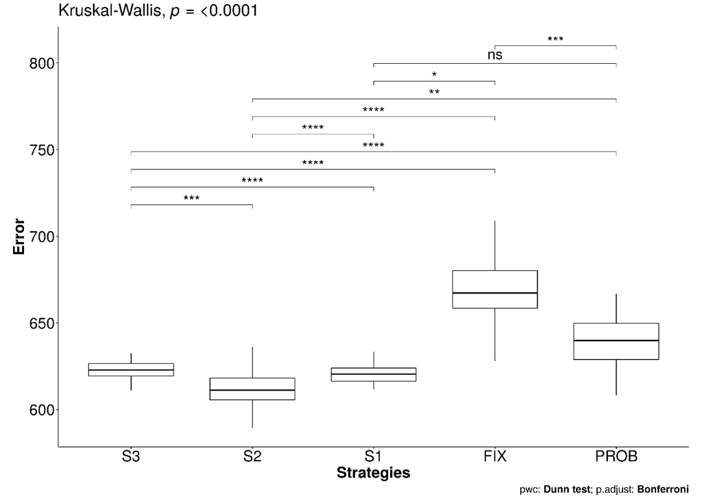

## **100D scenario**

**Function:** *f1**

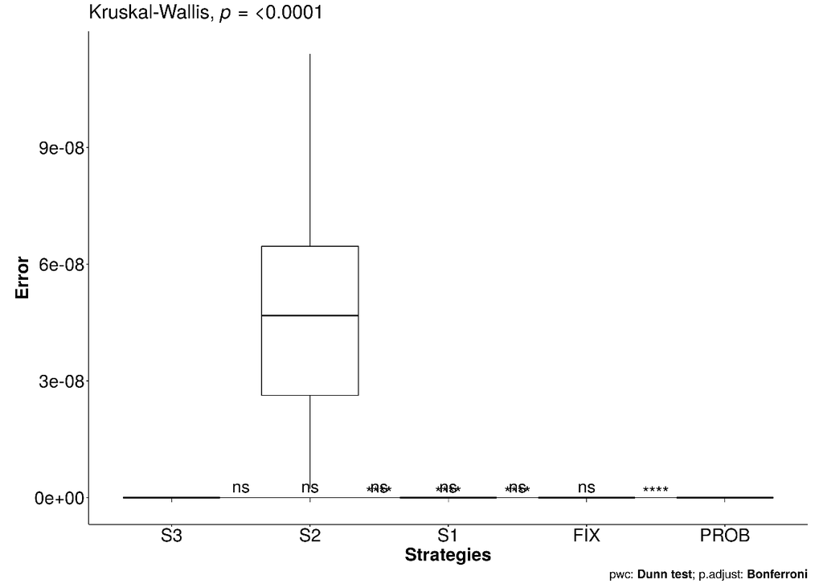

**Function:** *f2**

`Standard error of all strategies equal to or very close to zero.`

**Function:** *f3**

`Standard error of all strategies equal to or very close to zero.`

**Function:** *f4**

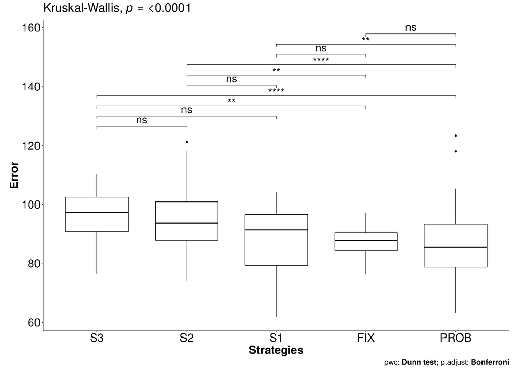

**Function:** *f5**

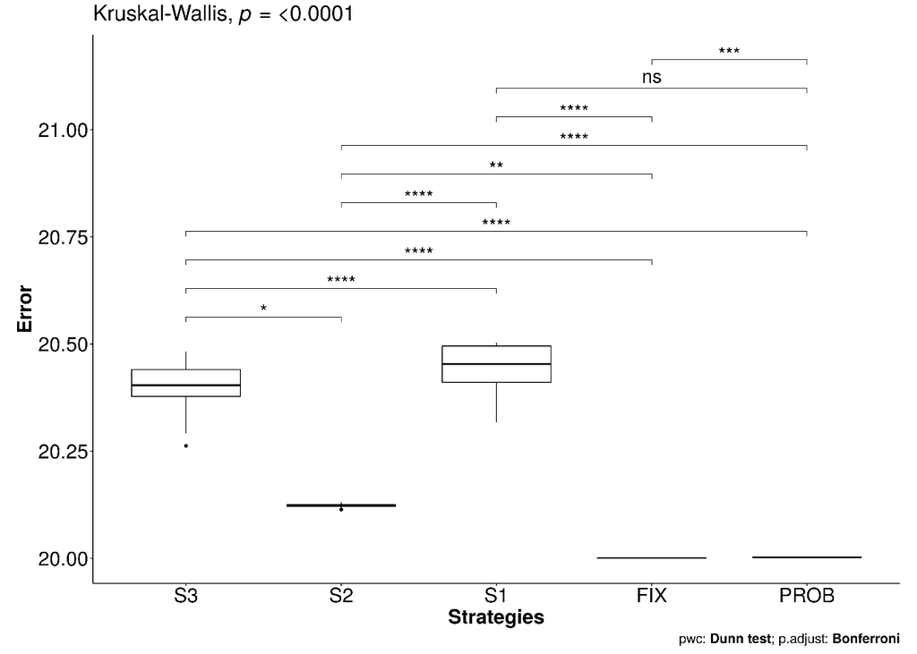

**Function:** *f6**

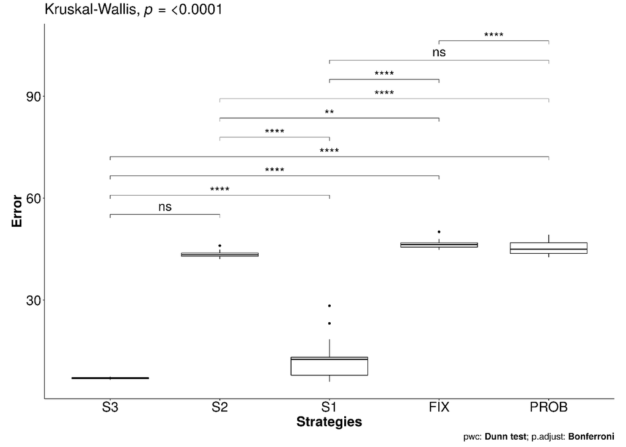

**Function:** *f7**

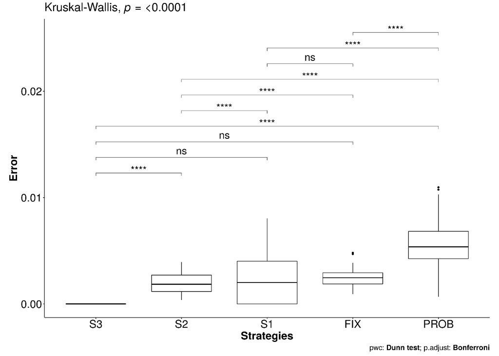

**Function:** *f8**

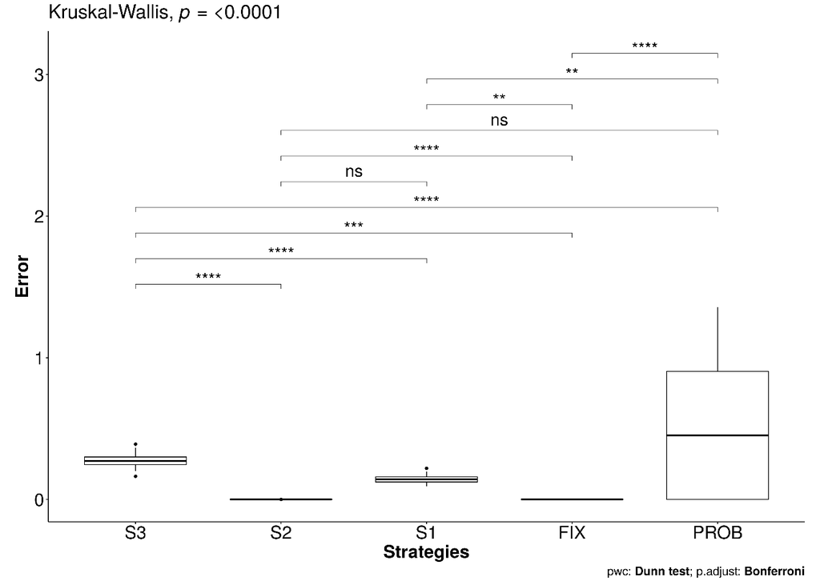

**Function:** *f9**

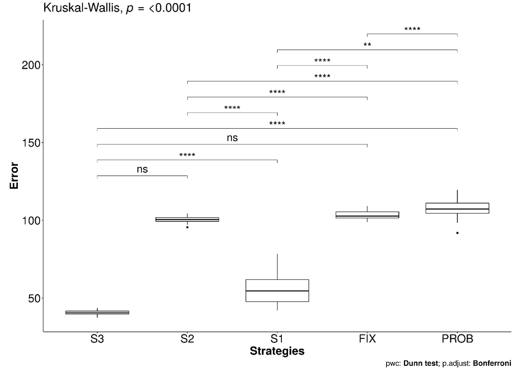

**Function:** *f10**

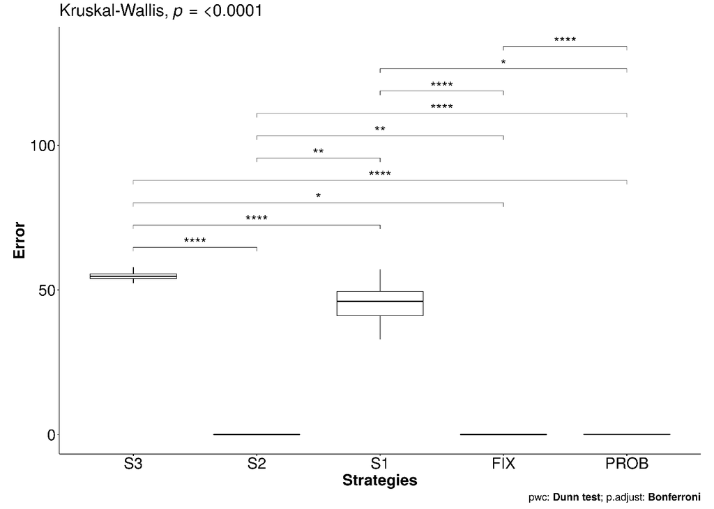

**Function:** *f11**

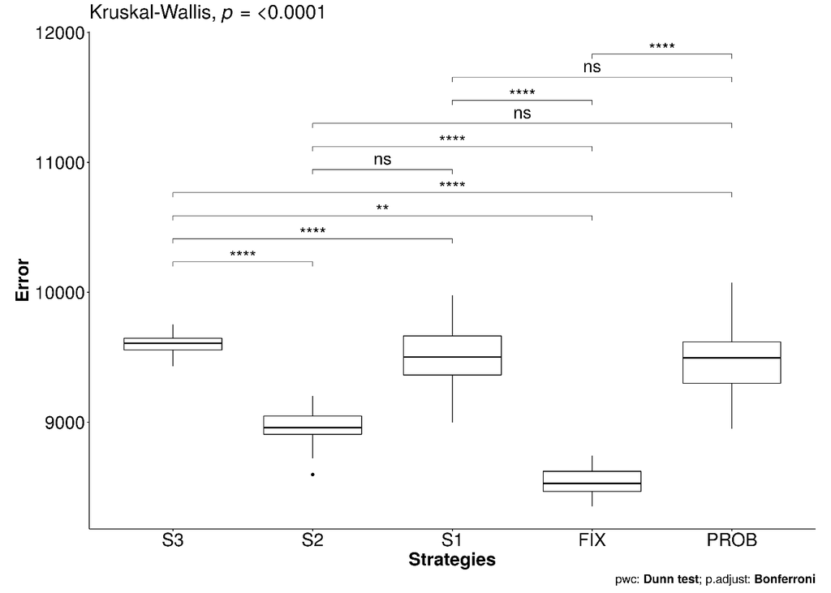

**Function:** *f12**

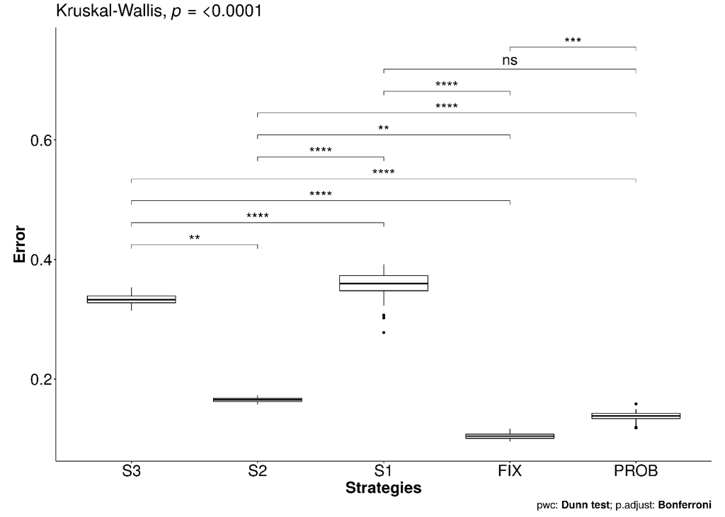

**Function:** *f13**

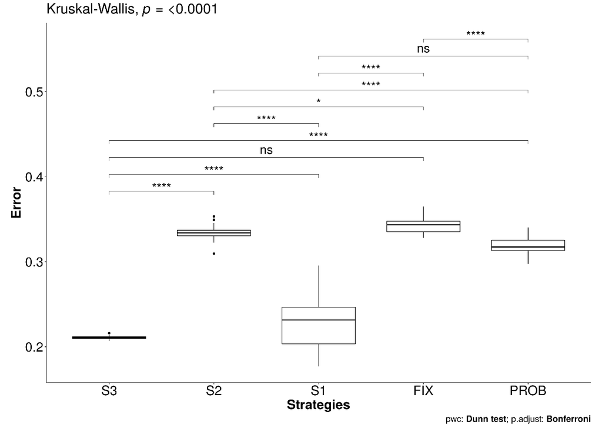

**Function:** *f14**

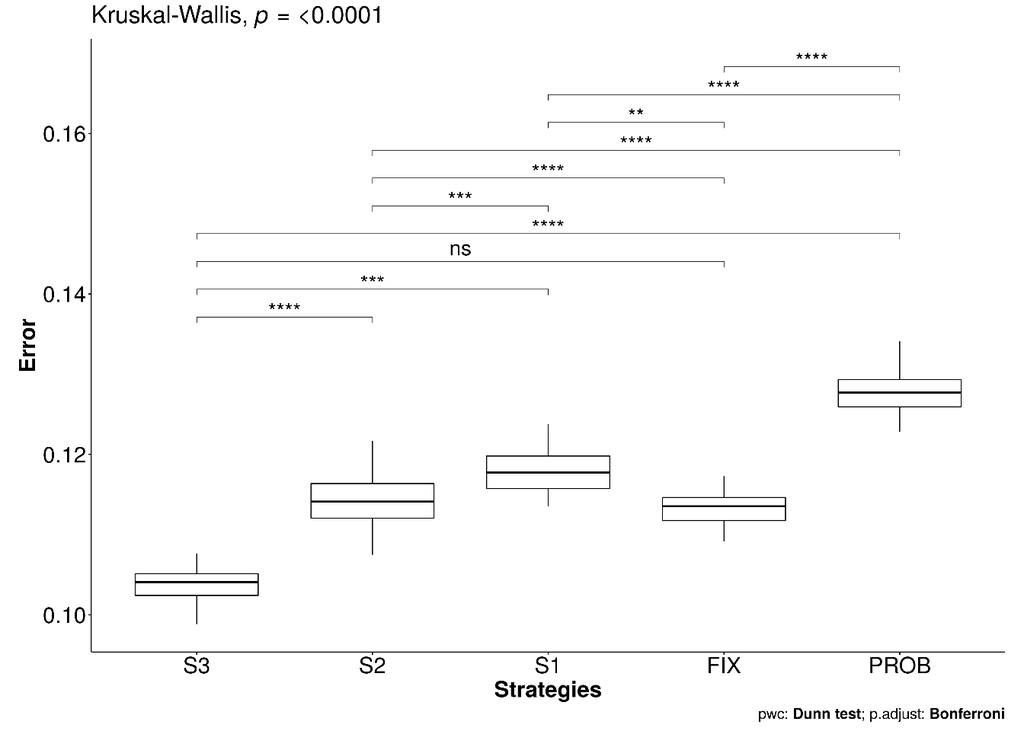

**Function:** *f15**

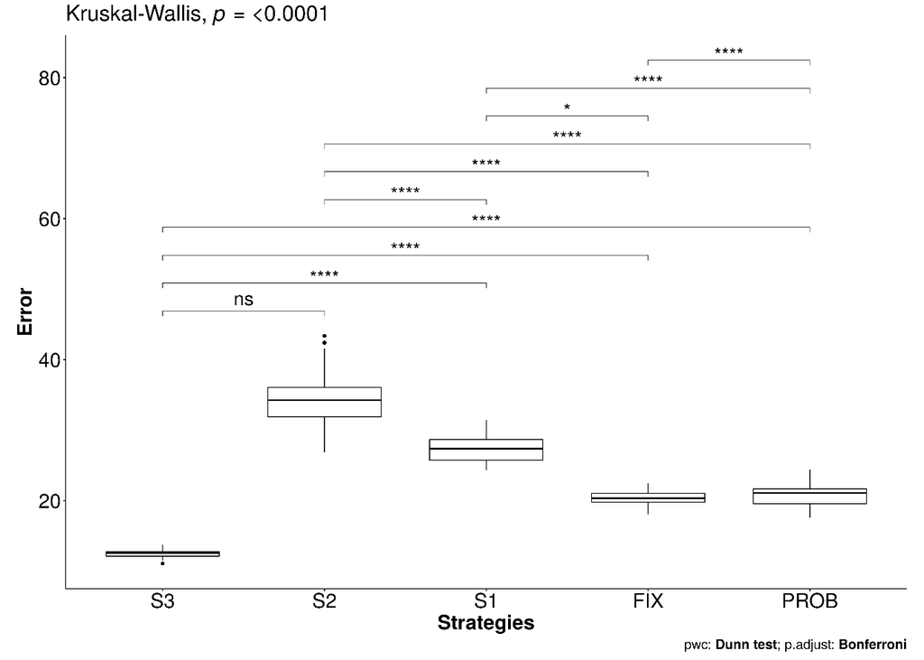

**Function:** *f16**

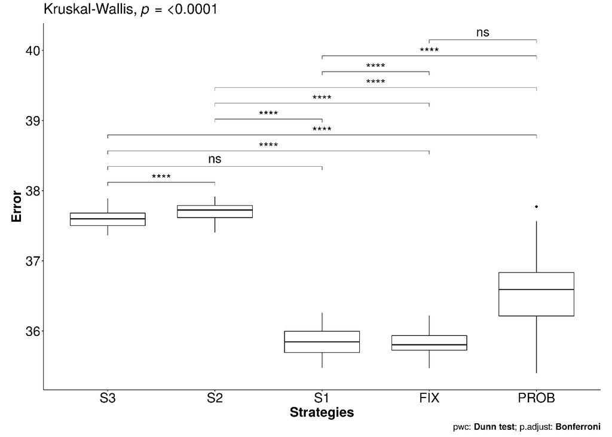

**Function:** *f17**

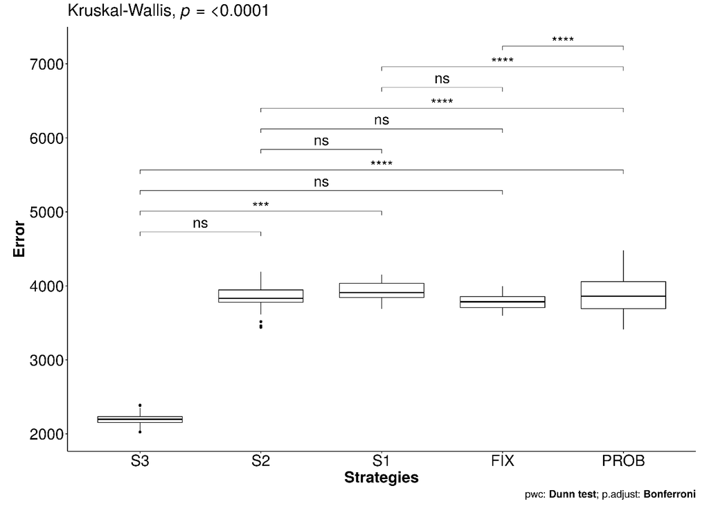

**Function:** *f18**

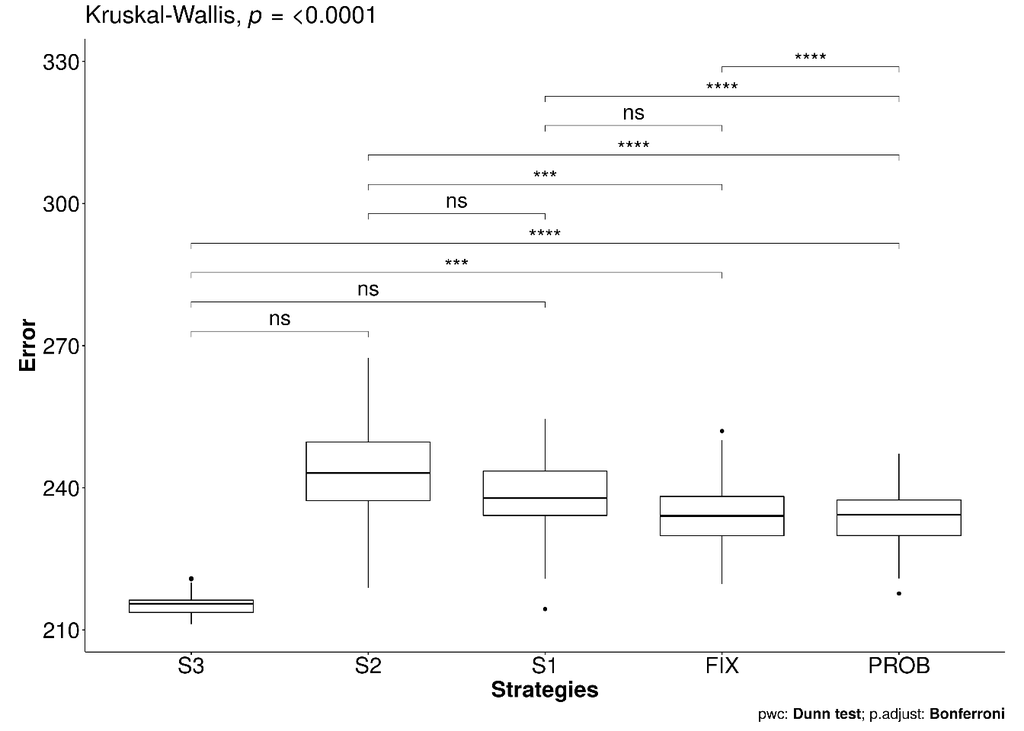

**Function:** *f19**

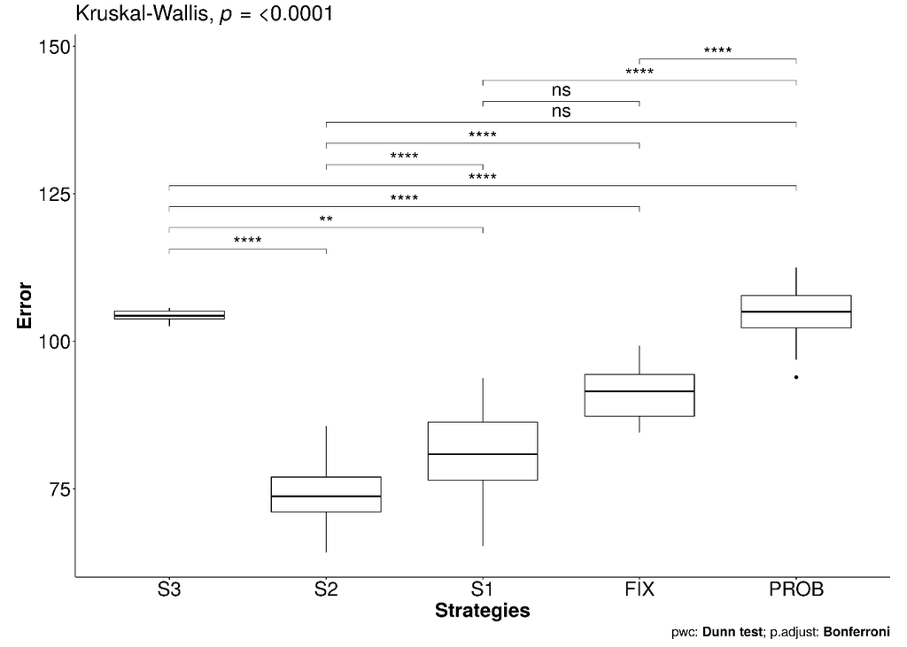

**Function:** *f20**

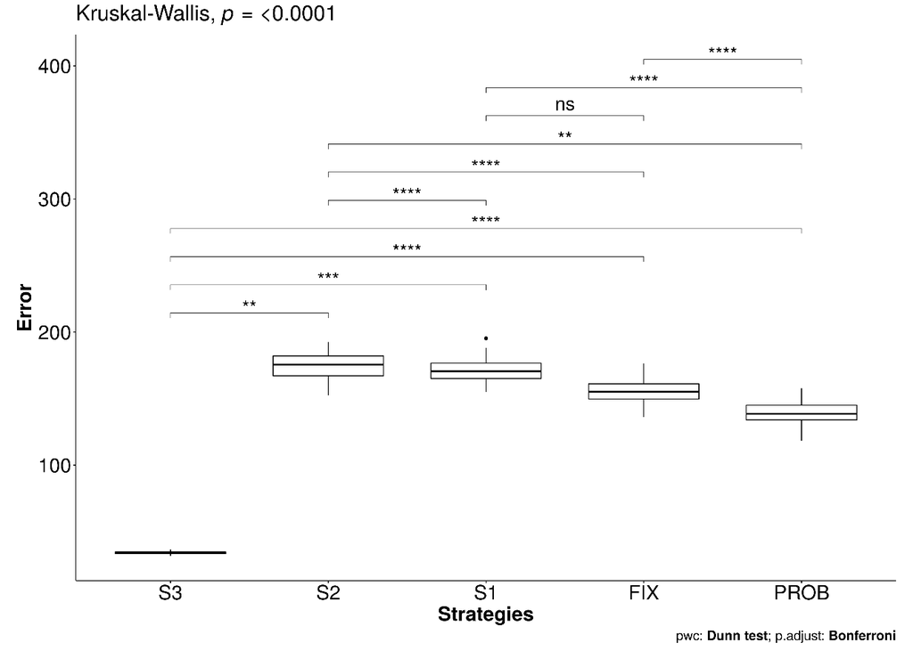

**Function:** *f21**

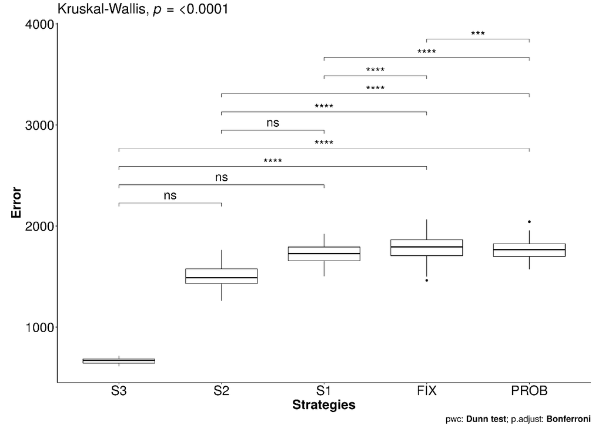

**Function:** *f22**

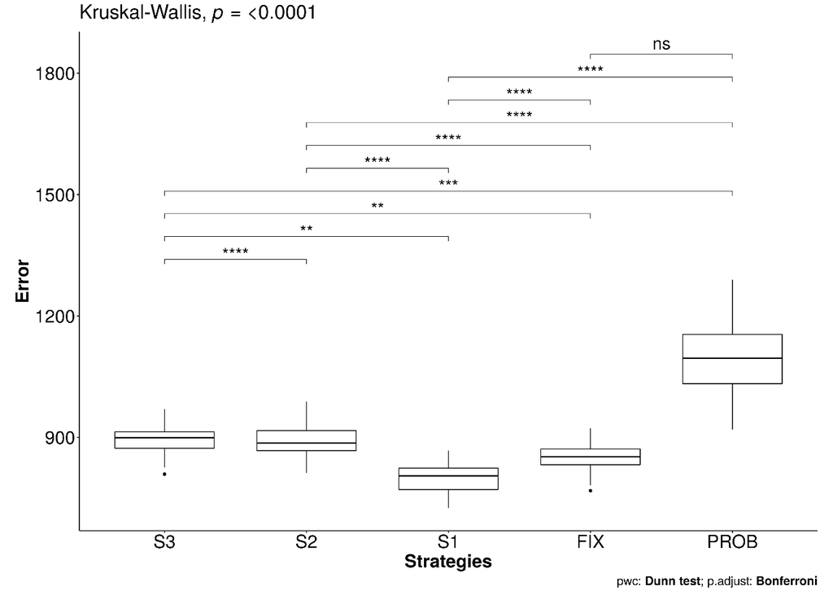

**Function:** *f23**

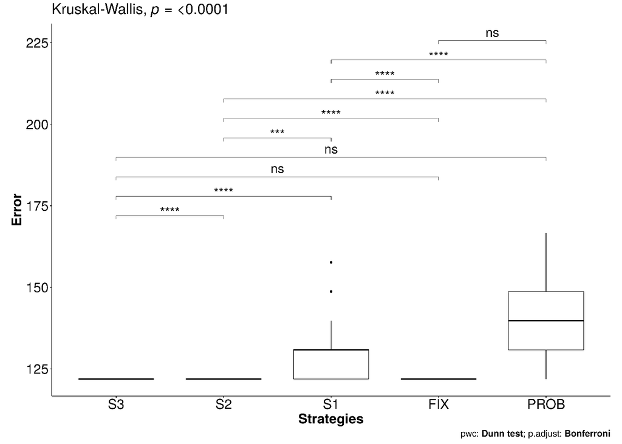

**Function:** *f24**

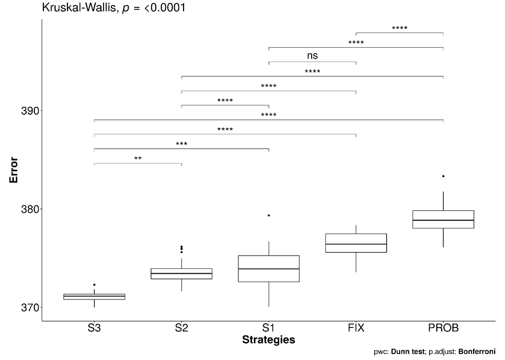

**Function:** *f25**

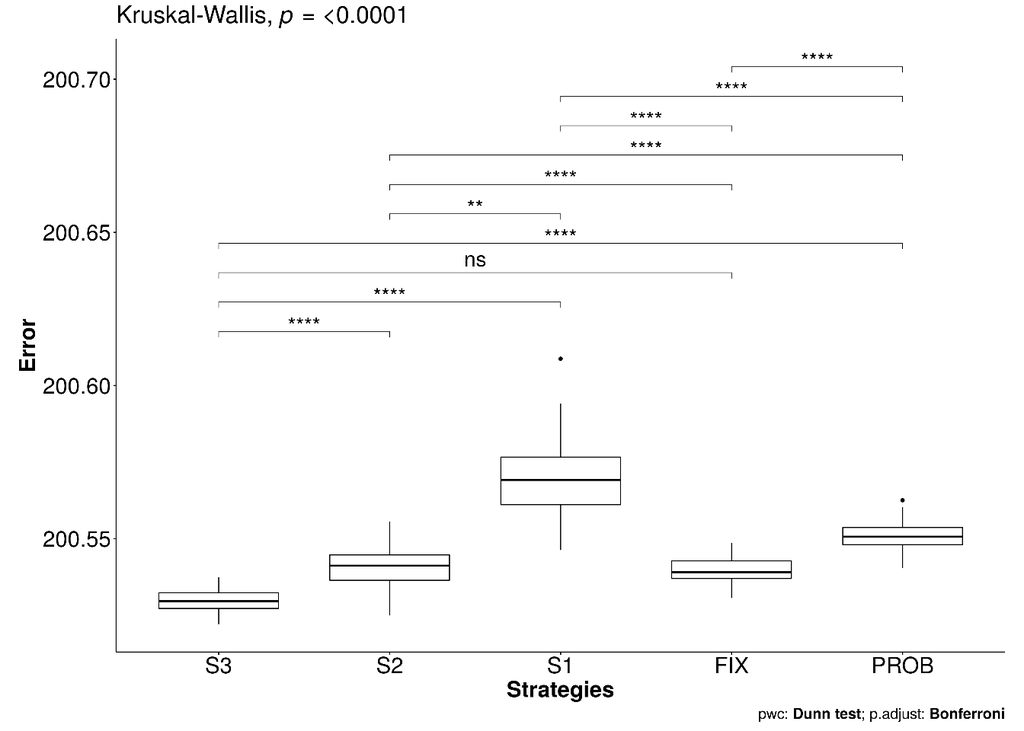

**Function:** *f26**

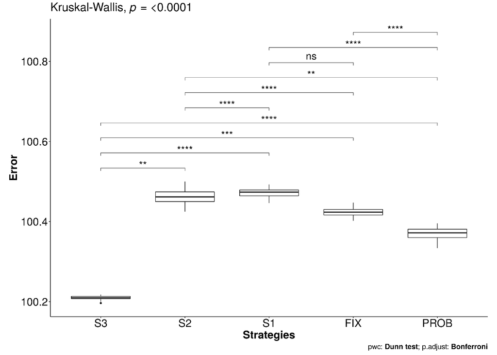

**Function:** *f27**

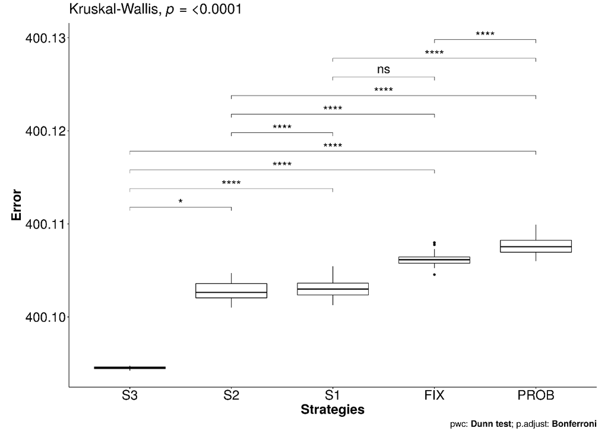

**Function:** *f28**

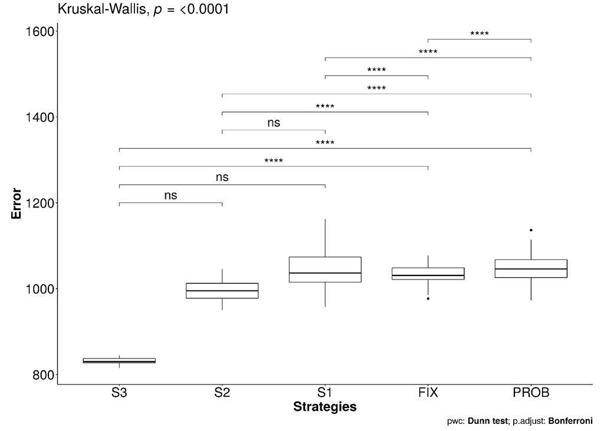

**Function:** *f29**

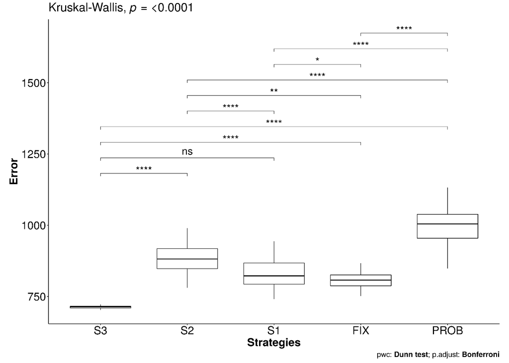

**Function:** *f30**

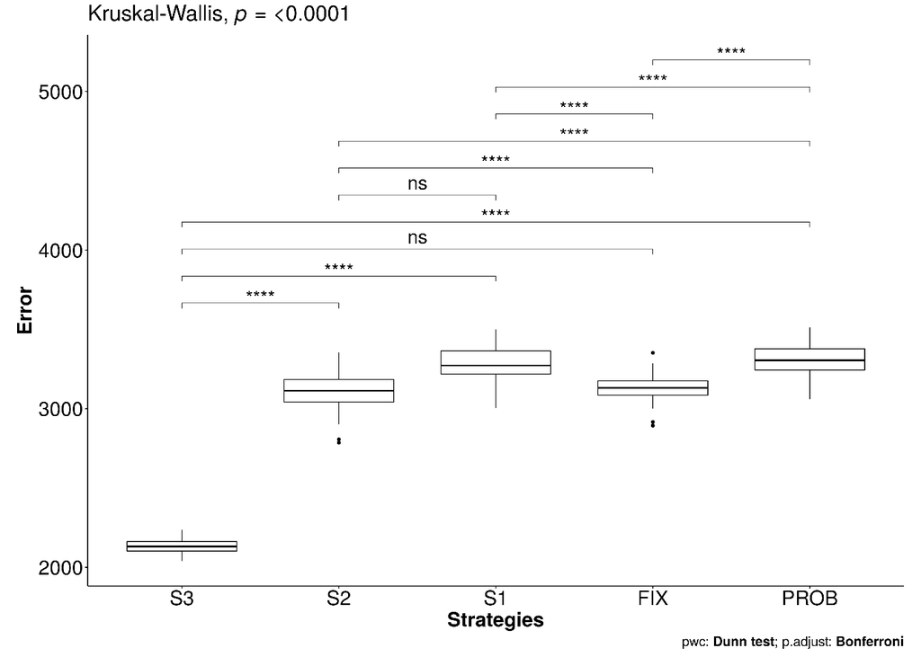